# Relatório de Unidade - Autoavaliação UFRPE 2019 (SEDE)

# 1 INTRODUÇÃO

Este relatório apresenta as respostas dos discentes, docentes e técnicos da Sede (Campus Dois Irmãos) (SEDE), referente à autoavaliação 2019 da Universidade Federal Rural de Pernambuco (UFRPE), conduzida pela Comissão Própria de Avaliação (CPA). Neste ano foram contemplados dois eixos avaliativos: Planejamento e Avaliação Institucional e Desenvolvimento Institucional.

Esta avaliação foi feita a partir de questionários online, disponibilizados de forma voluntária aos discentes, docentes e técnicos da instituição, no período de 23 de abril a 29 de julho de 2019. Maiores detalhes sobre a metodologia de autoavaliação podem ser encontrados no 2º Relatório Parcial de Autoavaliação Institucional (ANO-BASE 2019), disponível no site da [CPA/UFRPE](http://cpa.ufrpe.br/br/relatorio-de-autoavaliacao-institucional/).

Note que este relatório apresenta os resultados da avaliação da UFRPE *como um todo* sob o ponto de vista dos membros desta unidade; sendo assim, não pode ser interpretado como uma avaliação da unidade propriamente dita.

# 2 PANORAMA

Dentre os membros da comunidade acadêmica desta unidade aptos a participar da avaliação, 25.25% dos estudantes responderam ao questionário (1577 de 6245), 47.93% dos docentes responderam ao questionário (358 de 747), e 28.98% dos técnicos responderam ao questionário (262 de 904).

Os gráficos a seguir apresentam os resultados da avaliação de alguns itens pré-selecionados: Ações de Planejamento de Cursos e Utilização dos Resultados da Autoavaliação Institucional no Planejamento de Cursos, além da atuação da UFRPE na promoção do desenvolvimento econômico e social, da sustentabilidade, da igualdade étnico-racial, e na valorização da diversidade.

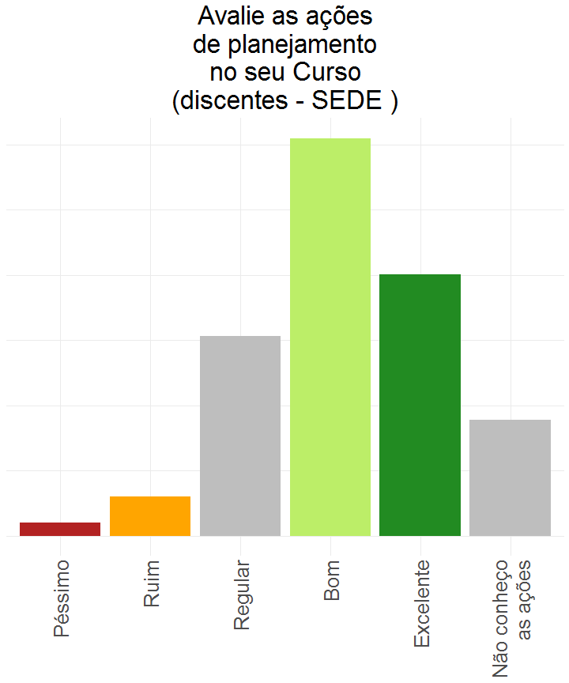

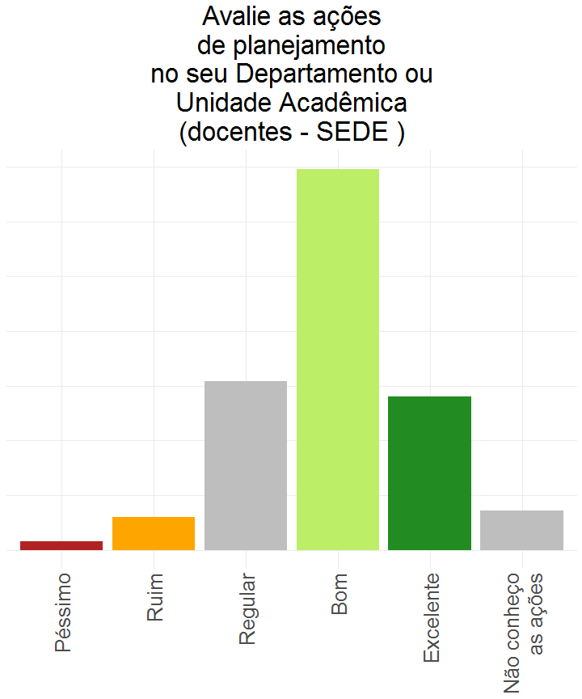

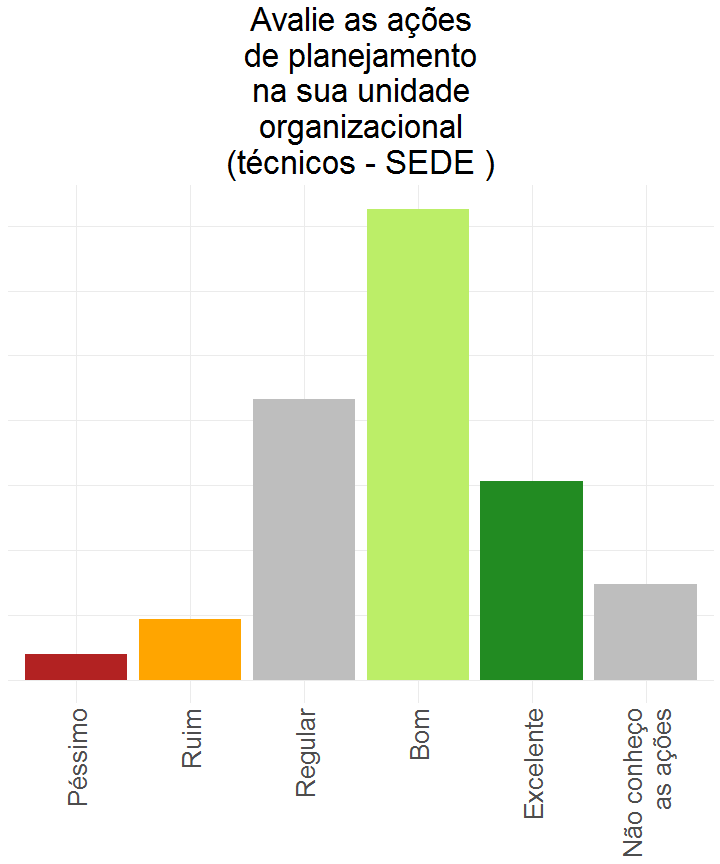

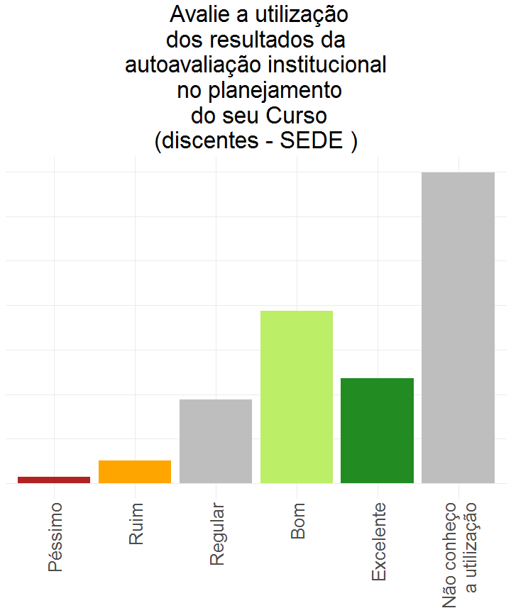

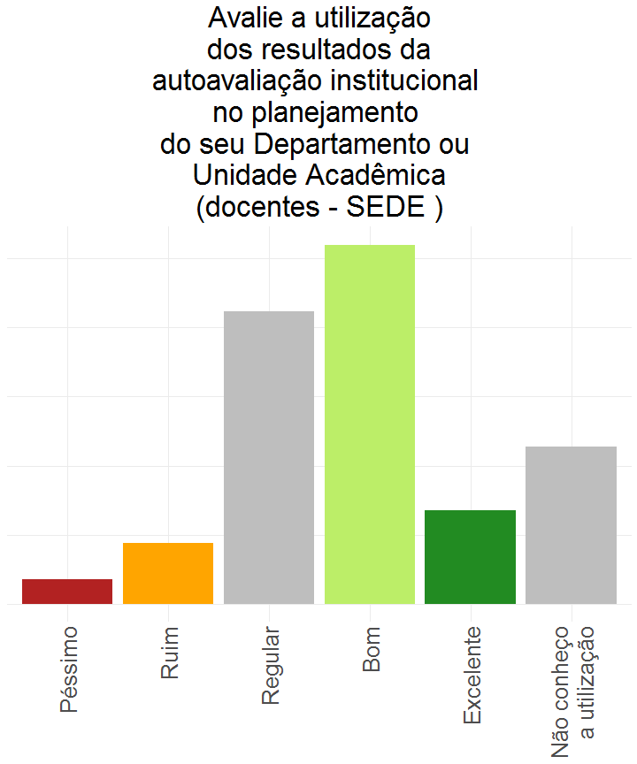

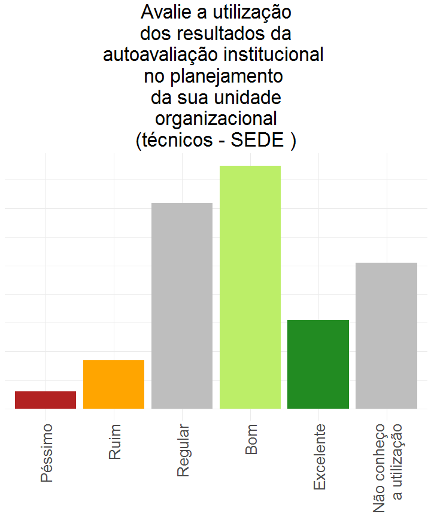

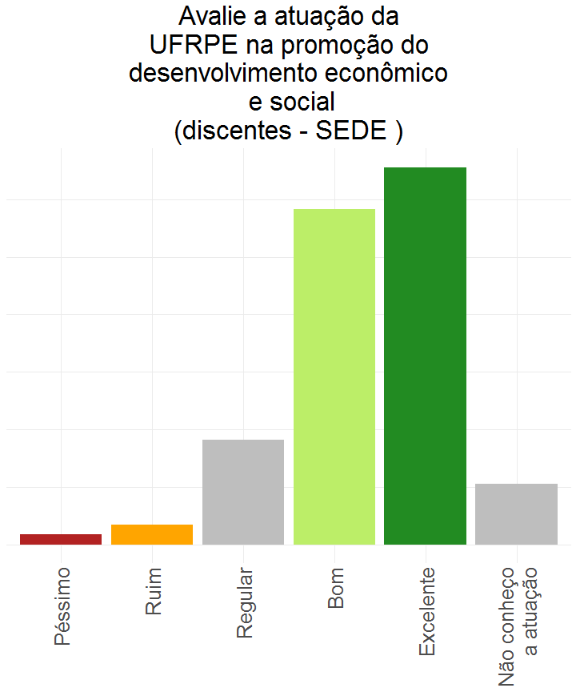

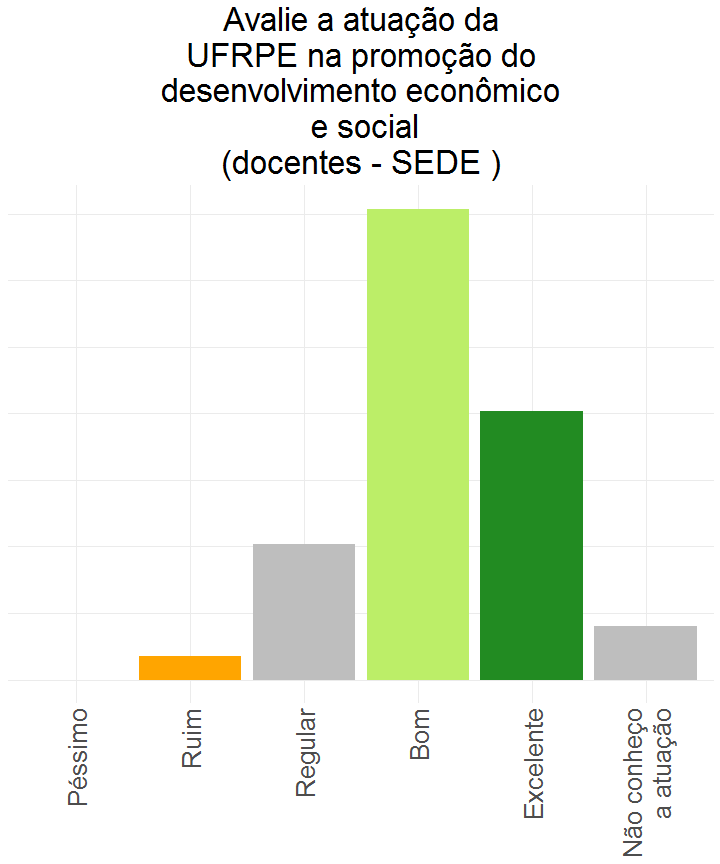

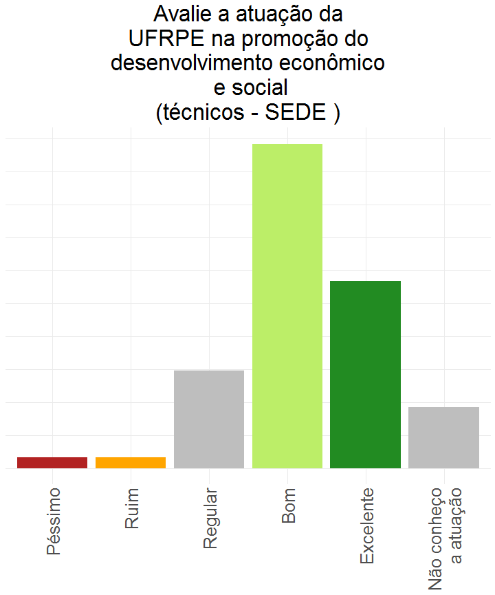

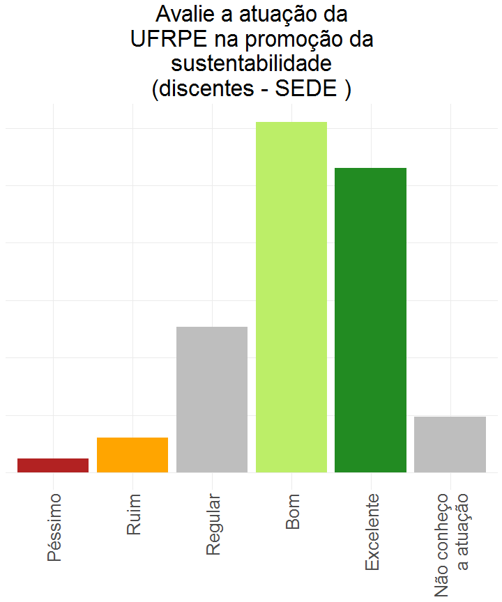

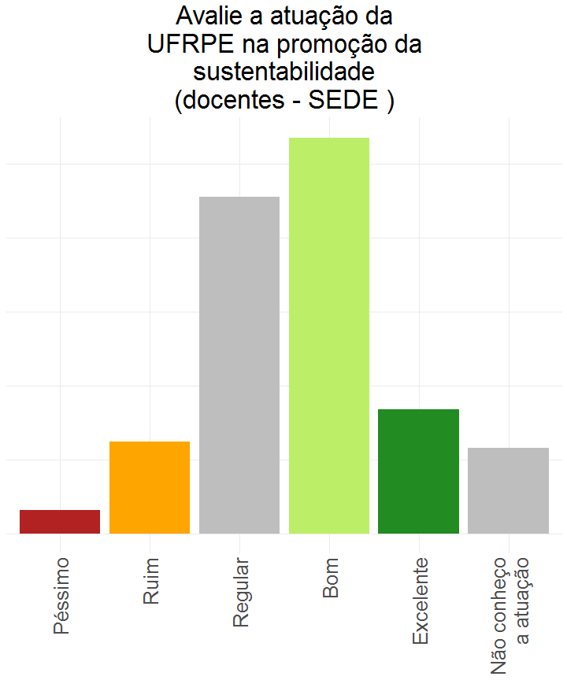

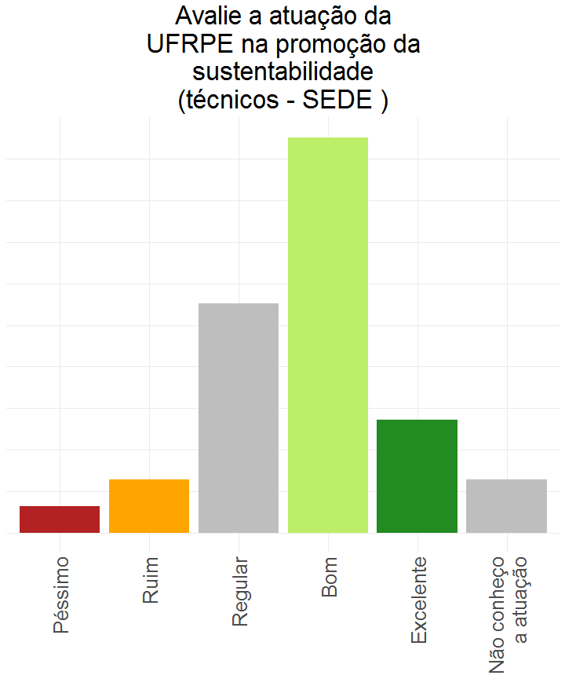

[6 more figures not shown]

# 3 DESTAQUES - PLANEJAMENTO E AVALIAÇÃO INSTITUCIONAL

Esta seção apresenta os resultados com maiores e menores médias numéricas referentes à avaliação do Planejamento e da Avaliação Institucional da UFRPE, conforme respondido pelos integrantes da Sede (Campus Dois Irmãos) (SEDE).

A seguir são apresentados os resultados classificados por segmento: discentes, docentes e técnicos.

## 3.1 Discentes (SEDE)

Durante o período de avaliação esta unidade contava com 6245 **discentes** aptos a participar da avaliação, dos quais 1577 (25.25%) responderam ao questionário. Do total das respostas referentes a Planejamento e Avaliação da instituição, 0.74% foram “péssimo”, 2.69% foram “ruim”, 13.52% foram “regular”, 33.41% foram “bom”, 26.88% foram “excelente”, e 22.76% foram outras opções de resposta.

### 3.1.1 Maiores médias:

Lista das 3 perguntas com respostas mais positivas, de um total de 6 perguntas, com base na média ponderada das respostas dos discentes desta unidade acadêmica.

| Item | Média |
| --- | --- |
| Avalie o acesso a este questionário de autoavaliação da UFRPE | 8.4 |
| Avalie o Projeto de Autoavaliação Institucional adotado pela Comissão Própria de Avaliação (CPA) | 7.9 |
| Avalie o acesso aos relatórios de autoavaliação da UFRPE | 7.7 |

### 3.1.2 Menores médias:

Lista das 3 perguntas com respostas mais negativas, de um total de 6 perguntas, com base na média ponderada das respostas dos discentes desta unidade.

| Item | Média |
| --- | --- |
| Avalie a visibilidade da Comissão Própria de Avaliação (CPA) nas Mídias Sociais (Facebook e Instagram) | 7.1 |
| Avalie a utilização dos resultados da autoavaliação institucional no planejamento do seu Curso | 7.2 |
| Avalie as ações de planejamento no seu curso | 7.3 |

## 3.2 Docentes (SEDE)

Durante o período de avaliação esta unidade contava com 747 **docentes** aptos a participar da avaliação, dos quais 358 (47.93%) responderam ao questionário. Do total das respostas referentes a Planejamento e Avaliação da instituição, 1.26% foram “péssimo”, 3.63% foram “ruim”, 18.44% foram “regular”, 41.2% foram “bom”, 20.44% foram “excelente”, e 15.04% foram outras opções de resposta.

### 3.2.1 Maiores médias:

Lista das 3 perguntas com respostas mais positivas, de um total de 6 perguntas, com base na média ponderada das respostas dos docentes desta unidade acadêmica.

| Item | Média |
| --- | --- |
| Avalie o acesso a este questionário de autoavaliação da UFRPE. | 8.2 |
| Avalie o acesso aos relatórios de autoavaliação da UFRPE | 7.5 |
| Avalie o Projeto de Autoavaliação Institucional adotado pela Comissão Própria de Avaliação (CPA) | 7.4 |

### 3.2.2 Menores médias:

Lista das 3 perguntas com respostas mais negativas, de um total de 6 perguntas, com base na média ponderada das respostas dos docentes desta unidade acadêmica.

| Item | Média |
| --- | --- |
| Avalie a utilização dos resultados da autoavaliação institucional no planejamento do seu Departamento ou Unidade Acadêmica | 6.3 |
| Avalie a visibilidade da Comissão Própria de Avaliação (CPA) nas Mídias Sociais (Facebook e Instagram) | 6.5 |
| Avalie as ações de planejamento no seu Departamento ou Unidade Acadêmica | 7.1 |

## 3.3 Técnicos (SEDE)

Durante o período de avaliação esta unidade contava com 904 **técnicos** aptos a participar da avaliação, dos quais 262 (28.98%) responderam ao questionário. Do total das respostas referentes a Planejamento e Avaliação da instituição, 1.27% foram “péssimo”, 3.94% foram “ruim”, 17.56% foram “regular”, 40.39% foram “bom”, 20.55% foram “excelente”, e 16.28% foram outras opções de resposta.

### 3.3.1 Maiores médias:

Lista das 3 perguntas com respostas mais positivas, de um total de 6 perguntas, com base na média ponderada das respostas dos técnicos desta unidade acadêmica.

| Item | Média |
| --- | --- |
| Avalie o acesso a este questionário de autoavaliação da UFRPE no site da Comissão Própria de Avaliaação (CPA) | 8.1 |
| Avalie o Projeto de Autoavaliação Institucional adotado pela Comissão Própria de Avaliação (CPA) | 7.6 |
| Avalie o acesso aos relatórios de autoavaliação da UFRPE | 7.5 |

### 3.3.2 Menores médias:

Lista das 3 perguntas com respostas mais negativas, de um total de 6 perguntas, com base na média ponderada das respostas dos técnicos desta unidade acadêmica.

| Item | Média |
| --- | --- |
| Avalie a utilização dos resultados da autoavaliação institucional no planejamento de sua unidade organizacional | 6.4 |
| Avalie as ações de planejamento na sua unidade organizacional | 6.8 |
| Avalie a visibilidade da Comissão Própria de Avaliação (CPA) nas Mídias Sociais (Facebook e Instagram) | 6.9 |

# 4 DESTAQUES - DESENVOLVIMENTO INSTITUCIONAL

Esta seção apresenta os resultados com maiores e menores médias numéricas referentes à avaliação do Desenvolvimento Institucional da UFRPE, conforme respondido pelos integrantes da Sede (Campus Dois Irmãos) (SEDE).

A seguir são apresentados os resultados classificados por segmento: discentes, docentes e técnicos.

## 4.1 Discentes (SEDE)

Durante o período de avaliação esta unidade contava com 6245 **discentes** aptos a participar da avaliação, dos quais 1577 (25.25%) responderam ao questionário. Do total das respostas referentes ao desenvolvimento institucional, 1.08% foram “péssimo”, 2.64% foram “ruim”, 12.49% foram “regular”, 31.33% foram “bom”, 31.04% foram “excelente”, e 21.43% foram outras opções de resposta.

### 4.1.1 Maiores médias:

Lista das 3 perguntas com respostas mais positivas, de um total de 11 perguntas, com base na média ponderada das respostas dos discentes desta unidade acadêmica.

| Item | Média |
| --- | --- |
| Avalie a atuação da UFRPE na promoção da igualdade étnico-racial | 8.5 |
| Avalie a atuação da UFRPE na valorização da diversidade | 8.5 |
| Avalie a atuação da UFRPE na promoção dos Direitos Humanos | 8.4 |

### 4.1.2 Menores médias:

Lista das 3 perguntas com respostas mais negativas, de um total de 11 perguntas, com base na média ponderada das respostas dos discentes desta unidade acadêmica.

| Item | Média |
| --- | --- |
| Avalie o seu conhecimento sobre o Plano de Desenvolvimento Institucional | 6.4 |
| Avalie seu conhecimento sobre o Plano de Gestão de Logística Sustentável (PLS) da UFRPE | 6.9 |
| Avalie a atuação da UFRPE na promoção da produção artística | 7.1 |

## 4.2 Docentes (SEDE)

Durante o período de avaliação esta unidade contava com 747 **docentes** aptos a participar da avaliação, dos quais 358 (47.93%) responderam ao questionário. Do total das respostas referentes ao desenvolvimento institucional, 1.17% foram “péssimo”, 4.37% foram “ruim”, 20.21% foram “regular”, 39.61% foram “bom”, 17.01% foram “excelente”, e 17.62% foram outras opções de resposta.

### 4.2.1 Maiores médias:

Lista das 3 perguntas com respostas mais positivas, de um total de 11 perguntas, com base na média ponderada das respostas dos docentes desta unidade acadêmica.

| Item | Média |
| --- | --- |
| Avalie a atuação da UFRPE na valorização da diversidade | 8.2 |
| Avalie a atuação da UFRPE na promoção da igualdade étnico-racial | 8.1 |
| Avalie a atuação da UFRPE na promoção dos Direitos Humanos | 7.8 |

### 4.2.2 Menores médias:

Lista das 3 perguntas com respostas mais negativas, de um total de 11 perguntas, com base na média ponderada das respostas dos docentes desta unidade acadêmica.

| Item | Média |
| --- | --- |
| Avalie seu conhecimento sobre o Plano de Gestão de Logística Sustentável (PLS) da UFRPE | 5.8 |
| Avalie a atuação da UFRPE na promoção da produção artística | 6.2 |
| Avalie o seu conhecimento sobre o Plano de Desenvolvimento Institucional (PDI) | 6.2 |

## 4.3 Técnicos (SEDE)

Durante o período de avaliação esta unidade contava com 904 **técnicos** aptos a participar da avaliação, dos quais 262 (28.98%) responderam ao questionário. Do total das respostas referentes ao desenvolvimento institucional, 1.67% foram “péssimo”, 3.61% foram “ruim”, 18.32% foram “regular”, 40.74% foram “bom”, 18.46% foram “excelente”, e 17.21% foram outras opções de resposta.

### 4.3.1 Maiores médias:

Lista das 3 perguntas com respostas mais positivas, de um total de 11 perguntas, com base na média ponderada das respostas dos técnicos desta unidade acadêmica.

| Item | Média |
| --- | --- |
| Avalie a atuação da UFRPE na valorização da diversidade | 8.1 |
| Avalie a atuação da UFRPE na promoção da igualdade étnico-racial | 8.0 |
| Avalie a atuação da UFRPE na promoção dos Direitos Humanos | 7.8 |

### 4.3.2 Menores médias:

Lista das 3 perguntas com respostas mais negativas, de um total de 11 perguntas, com base na média ponderada das respostas dos técnicos desta unidade acadêmica.

| Item | Média |
| --- | --- |
| Avalie o seu conhecimento sobre o Plano de Desenvolvimento Institucional (PDI) | 6.2 |
| Avalie seu conhecimento sobre o Plano de Gestão de Logística Sustentável (PLS) da UFRPE | 6.3 |
| Avalie a atuação da UFRPE na promoção da sustentabilidade | 6.6 |

# 5 RESULTADOS COMPLETOS

Esta seção apresenta as tabelas com as respostas a todas as perguntas do questionário de avaliação UFRPE 2019, conforme respondido pelos integrantes desta unidade, classificadas por segmento.

## 5.1 Planejamento e Avaliação Institucional

### 5.1.1 Discentes (SEDE)

Resultados da avaliação de **Planejamento e Avaliação Institucional** da UFRPE, conforme respondido pelos discentes desta unidade acadêmica.

| Média | Item | Péssimo (0) | Ruim (2.5) | Regular (5) | Bom (7.5) | Excelente (10) | OOR* |
| --- | --- | --- | --- | --- | --- | --- | --- |
| 8.4 | Avalie o acesso a este questionário de autoavaliação da UFRPE | 10 | 24 | 130 | 615 | 798 | 0 |
| 7.9 | Avalie o Projeto de Autoavaliação Institucional adotado pela Comissão Própria de Avaliação (CPA) | 5 | 14 | 171 | 571 | 381 | 435 |
| 7.7 | Avalie o acesso aos relatórios de autoavaliação da UFRPE | 6 | 44 | 226 | 584 | 447 | 270 |
| 7.3 | Avalie as ações de planejamento no seu curso | 20 | 61 | 307 | 610 | 401 | 178 |
| 7.2 | Avalie a utilização dos resultados da autoavaliação institucional no planejamento do seu Curso | 15 | 51 | 188 | 388 | 236 | 699 |
| 7.1 | Avalie a visibilidade da Comissão Própria de Avaliação (CPA) nas Mídias Sociais (Facebook e Instagram) | 14 | 61 | 257 | 393 | 280 | 572 |

*OOR: Outras opções de resposta

### 5.1.2 Docentes (SEDE)

Resultados da avaliação de Planejamento e Avaliação Institucional da UFRPE, conforme respondido pelos docentes desta unidade acadêmica.

| Média | Item | Péssimo (0) | Ruim (2.5) | Regular (5) | Bom (7.5) | Excelente (10) | OOR* |
| --- | --- | --- | --- | --- | --- | --- | --- |
| 8.2 | Avalie o acesso a este questionário de autoavaliação da UFRPE. | 2 | 5 | 42 | 146 | 163 | 0 |
| 7.5 | Avalie o acesso aos relatórios de autoavaliação da UFRPE | 4 | 11 | 52 | 162 | 84 | 45 |
| 7.4 | Avalie o Projeto de Autoavaliação Institucional adotado pela Comissão Própria de Avaliação (CPA) | 3 | 1 | 50 | 160 | 52 | 92 |
| 7.1 | Avalie as ações de planejamento no seu Departamento ou Unidade Acadêmica | 4 | 15 | 77 | 174 | 70 | 18 |
| 6.5 | Avalie a visibilidade da Comissão Própria de Avaliação (CPA) nas Mídias Sociais (Facebook e Instagram) | 5 | 24 | 69 | 113 | 36 | 111 |
| 6.3 | Avalie a utilização dos resultados da autoavaliação institucional no planejamento do seu Departamento ou Unidade Acadêmica | 9 | 22 | 106 | 130 | 34 | 57 |

*OOR: Outras opções de resposta

### 5.1.3 Técnicos (SEDE)

Resultados da avaliação de Planejamento e Avaliação Institucional da UFRPE, conforme respondido pelos técnicos desta unidade acadêmica.

| Média | Item | Péssimo (0) | Ruim (2.5) | Regular (5) | Bom (7.5) | Excelente (10) | OOR* |
| --- | --- | --- | --- | --- | --- | --- | --- |
| 8.1 | Avalie o acesso a este questionário de autoavaliação da UFRPE no site da Comissão Própria de Avaliaação (CPA) | 3 | 6 | 27 | 108 | 106 | 12 |
| 7.6 | Avalie o Projeto de Autoavaliação Institucional adotado pela Comissão Própria de Avaliação (CPA) | 1 | 5 | 25 | 129 | 45 | 57 |
| 7.5 | Avalie o acesso aos relatórios de autoavaliação da UFRPE | 1 | 10 | 37 | 116 | 61 | 37 |
| 6.9 | Avalie a visibilidade da Comissão Própria de Avaliação (CPA) nas Mídias Sociais (Facebook e Instagram) | 3 | 10 | 50 | 88 | 34 | 77 |
| 6.8 | Avalie as ações de planejamento na sua unidade organizacional | 6 | 14 | 65 | 109 | 46 | 22 |
| 6.4 | Avalie a utilização dos resultados da autoavaliação institucional no planejamento de sua unidade organizacional | 6 | 17 | 72 | 85 | 31 | 51 |

*OOR: Outras opções de resposta

## 5.2 Desenvolvimento Institucional

### 5.2.1 Discentes (SEDE)

Resultados da avaliação do **Desenvolvimento Institucional** da UFRPE, conforme respondido pelos discentes desta unidade acadêmica.

| Média | Item | Péssimo (0) | Ruim (2.5) | Regular (5) | Bom (7.5) | Excelente (10) | OOR* |
| --- | --- | --- | --- | --- | --- | --- | --- |
| 8.5 | Avalie a atuação da UFRPE na promoção da igualdade étnico-racial | 10 | 18 | 137 | 522 | 814 | 76 |
| 8.5 | Avalie a atuação da UFRPE na valorização da diversidade | 13 | 29 | 119 | 510 | 810 | 96 |
| 8.4 | Avalie a atuação da UFRPE na promoção dos Direitos Humanos | 12 | 15 | 137 | 581 | 731 | 101 |
| 8.1 | Avalie a atuação da UFRPE na promoção do desenvolvimento econômico e social | 17 | 34 | 182 | 583 | 656 | 105 |
| 7.9 | Avalie a atuação da UFRPE na gestão do patrimônio cultural | 19 | 41 | 215 | 563 | 560 | 179 |
| 7.8 | Avalie o Plano de Desenvolvimento Institucional (PDI) da UFRPE como instrumento de gestão (Planejamento, execução e avaliação) | 9 | 12 | 135 | 436 | 277 | 708 |
| 7.7 | Avalie o alinhamento das diretrizes e objetivos estratégicos do Plano de Desenvolvimento Institucional (PDI) com as ações executadas na UFRPE | 6 | 9 | 146 | 445 | 239 | 732 |
| 7.6 | Avalie a atuação da UFRPE na promoção da sustentabilidade | 24 | 61 | 254 | 611 | 530 | 97 |
| 7.1 | Avalie a atuação da UFRPE na promoção da produção artística | 40 | 88 | 325 | 516 | 414 | 194 |
| 6.9 | Avalie seu conhecimento sobre o Plano de Gestão de Logística Sustentável (PLS) da UFRPE | 15 | 55 | 226 | 308 | 197 | 776 |
| 6.4 | Avalie o seu conhecimento sobre o Plano de Desenvolvimento Institucional | 22 | 96 | 290 | 359 | 157 | 653 |

*OOR: Outras opções de resposta

### 5.2.2 Docentes (SEDE)

Resultados da avaliação do Desenvolvimento Institucional da UFRPE, conforme respondido pelos docentes desta unidade acadêmica.

| Média | Item | Péssimo (0) | Ruim (2.5) | Regular (5) | Bom (7.5) | Excelente (10) | OOR* |
| --- | --- | --- | --- | --- | --- | --- | --- |
| 8.2 | Avalie a atuação da UFRPE na valorização da diversidade | 0 | 2 | 31 | 166 | 131 | 28 |
| 8.1 | Avalie a atuação da UFRPE na promoção da igualdade étnico-racial | 1 | 4 | 31 | 165 | 125 | 32 |
| 7.8 | Avalie a atuação da UFRPE na promoção dos Direitos Humanos | 1 | 3 | 53 | 169 | 100 | 32 |
| 7.7 | Avalie a atuação da UFRPE na promoção do desenvolvimento econômico e social | 0 | 9 | 51 | 177 | 101 | 20 |
| 7.1 | Avalie o PDI da UFRPE como instrumento de gestão ( Planejamento, execução e avaliação) | 0 | 8 | 66 | 157 | 40 | 87 |
| 6.7 | Avalie o alinhamento das diretrizes e objetivos estratégicos do PDI com as as ações executadas na UFRPE | 2 | 12 | 84 | 142 | 28 | 90 |
| 6.3 | Avalie a atuação da UFRPE na gestão de patrimônio cultural | 12 | 19 | 90 | 135 | 31 | 71 |
| 6.3 | Avalie a atuação da UFRPE na promoção da sustentabilidade | 8 | 31 | 114 | 134 | 42 | 29 |
| 6.2 | Avalie a atuação da UFRPE na promoção da produção artística | 9 | 33 | 96 | 123 | 34 | 63 |
| 6.2 | Avalie o seu conhecimento sobre o Plano de Desenvolvimento Institucional (PDI) | 4 | 27 | 111 | 123 | 23 | 70 |
| 5.8 | Avalie seu conhecimento sobre o Plano de Gestão de Logística Sustentável (PLS) da UFRPE | 9 | 24 | 69 | 69 | 15 | 172 |

*OOR: Outras opções de resposta

### 5.2.3 Técnicos (SEDE)

Resultados da avaliação do Desenvolvimento Institucional da UFRPE, conforme respondido pelos técnicos desta unidade acadêmica.

| Média | Item | Péssimo (0) | Ruim (2.5) | Regular (5) | Bom (7.5) | Excelente (10) | OOR* |
| --- | --- | --- | --- | --- | --- | --- | --- |
| 8.1 | Avalie a atuação da UFRPE na valorização da diversidade | 4 | 2 | 21 | 120 | 95 | 20 |
| 8.0 | Avalie a atuação da UFRPE na promoção da igualdade étnico-racial | 3 | 1 | 25 | 124 | 87 | 22 |
| 7.8 | Avalie a atuação da UFRPE na promoção dos Direitos Humanos | 4 | 2 | 33 | 121 | 75 | 27 |
| 7.6 | Avalie a atuação da UFRPE na promoção do desenvolvimento econômico e social | 4 | 4 | 37 | 123 | 71 | 23 |
| 7.1 | Avalie o Plano de Desenvolvimento Institucional (PDI) da UFRPE como instrumento de gestão ( Planejamento, execução e avaliação) | 2 | 8 | 43 | 106 | 34 | 69 |
| 6.8 | Avalie a atuação da UFRPE na gestão do patrimônio cultural | 7 | 13 | 48 | 117 | 33 | 44 |
| 6.7 | Avalie a atuação da UFRPE na promoção da produção artística | 3 | 14 | 62 | 106 | 32 | 45 |
| 6.6 | Avalie a atuação da UFRPE na promoção da sustentabilidade | 8 | 16 | 69 | 119 | 34 | 16 |
| 6.6 | Avalie o alinhamento das diretrizes e objetivos estratégicos do Plano de Desenvolvimento Institucional (PDI) com as ações executadas na UFRPE | 3 | 11 | 55 | 100 | 21 | 72 |
| 6.3 | Avalie seu conhecimento sobre o Plano de Gestão de Logística Sustentável (PLS) da UFRPE | 5 | 16 | 58 | 59 | 26 | 98 |
| 6.2 | Avalie o seu conhecimento sobre o Plano de Desenvolvimento Institucional (PDI) | 5 | 17 | 77 | 79 | 24 | 60 |

*OOR: Outras opções de resposta